# Profiles

Jonas BEAL

24/01/2020

## 0.1 Objectives

Generate patients profiles from cell Lines data for further logical modelling. Datafiles have been downloaded from CellModelPassports portal (omics profiles and CRISPR/Cas9 screening) and GDSC database (drug screening)

# 1 Independent omics profiles

## 1.1 Cell Model Passports dataset recap

More than 1000 cell lines with several kinds of omics data: exome-sequencing, Copy Number Alterations (CNA), RNA and clinical annotations. Here we focus on melanoma and colorectal cancer.

Many patients have all omics data and even drug screening information. Only CRISPR/Cas9 is more rare:

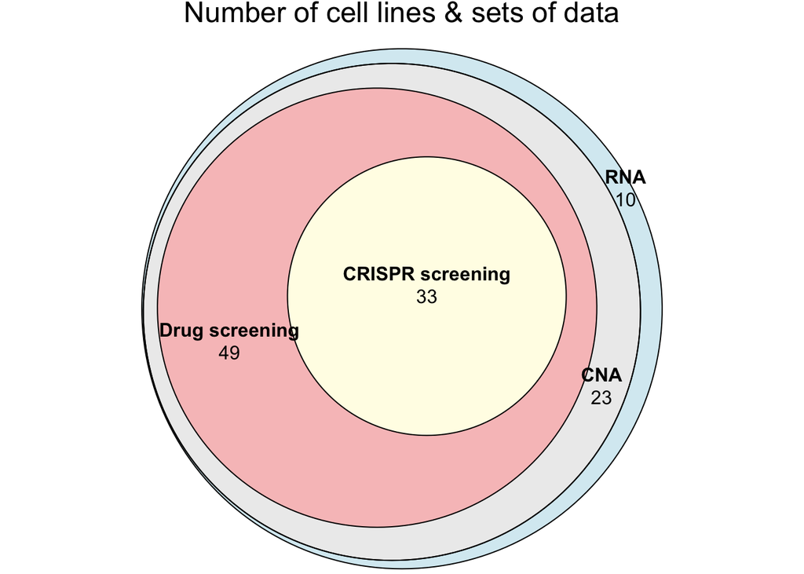

And almost all genes related to the model have corresponding data for all omics:

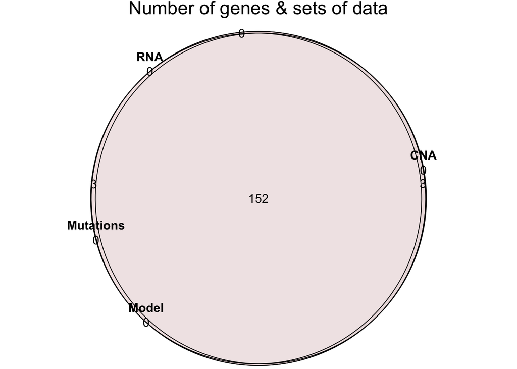

# 2 Processing pipeline

## 2.1 Mutations profiles

We need to assign Boolean effects to mutations: either 0 (inactivating) or 1 (activating). A mutation can stay unassigned in absence of any evidence. Several assignment methods are proposed in the code, based on different levels of evidence. In the article we decided to focus only only the OncoKB curated database to include only high-confidence functional inference of mutations.

Assignement methods and their respective influence:

```
## [1] "Sankey plots of mutation assignments depending on methods used"
```

[interactive chart not shown]

```
## [1] "Sankey plots of mutation assignments depending on methods used (restricted to model-related nodes)"
```

[interactive chart not shown]

Now we can summarize patient mutations profiles after processing. In following plots we focus on model-related genes only.

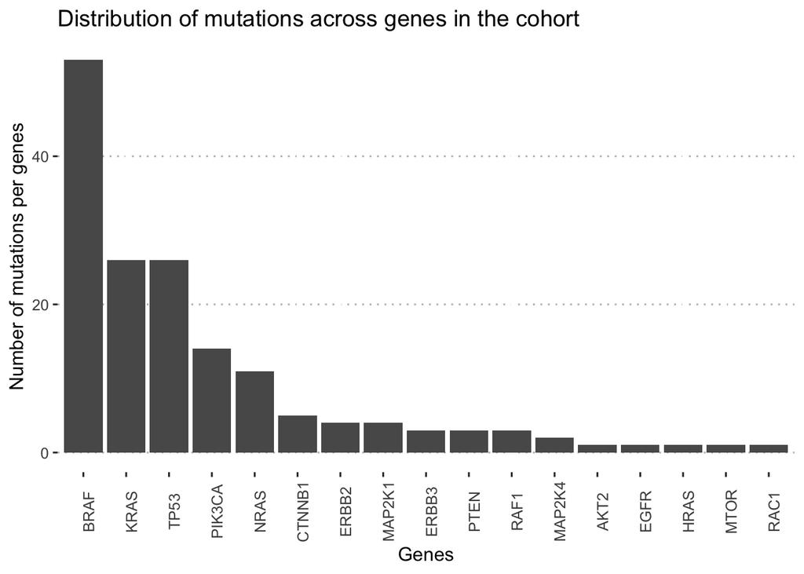

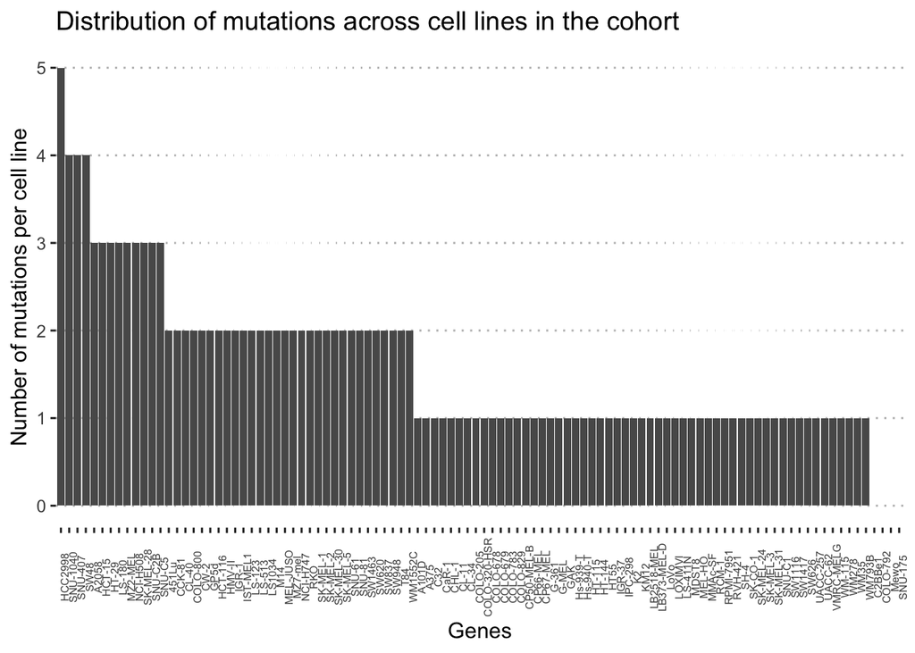

## 2.2 CNA profiles

For CNA, we have decided to focus on stringent amplifications/deletions corresponding to +2/-2 GISTIC results. We produce the same kind of plots.

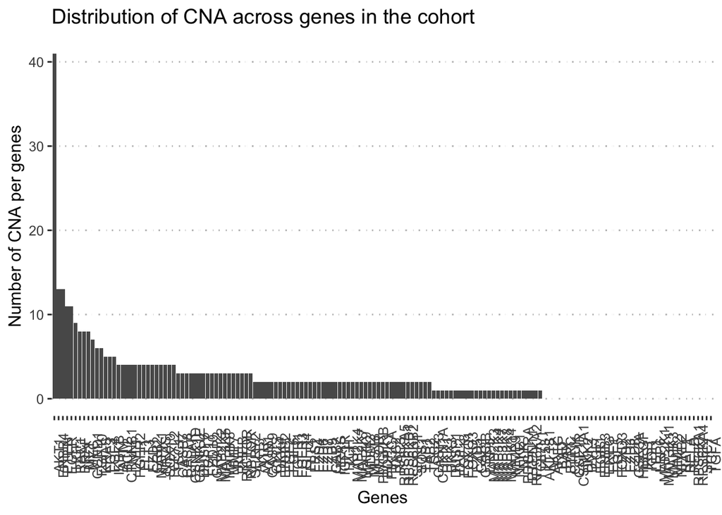

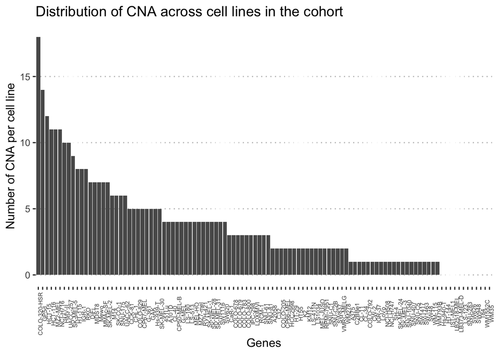

## 2.3 RNA profiles

RNA data is intrinsically continuous and therefore require preliminary data processing. We provide here some code for both binarization and normalization of RNA data. Please note that only normalization of RNA data has been used in the article (for continuous personalization of logical models). However, the reader might be interested by binarization of continuous data and further use for discrete personalization in other applications.

### 2.3.1 Binarization with classification tree

Now, what about the distribution of gene categories (Bimodal, Unimodal...) across the cohort?

```
## [1] "CL assignments for model-related nodes:"
```

| Bimodal | Discarded | Unimodal | ZeroInf |
| --- | --- | --- | --- |
| 15 | 12 | 108 | 23 |

Here are some distributions plots randomly picked in each category in CL cohort

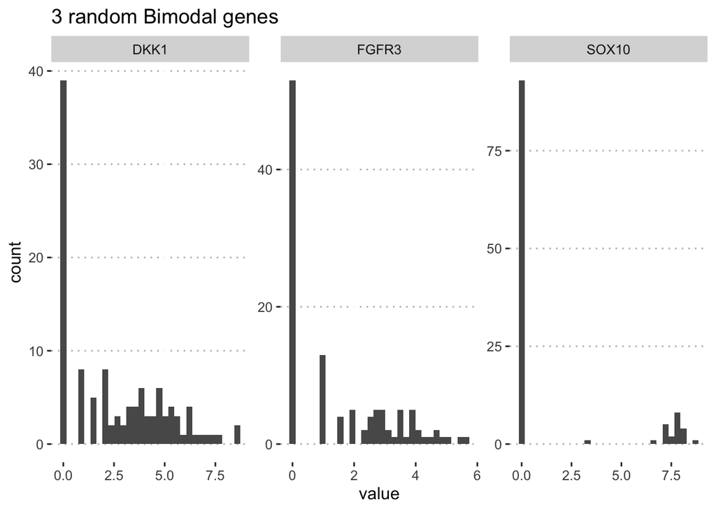

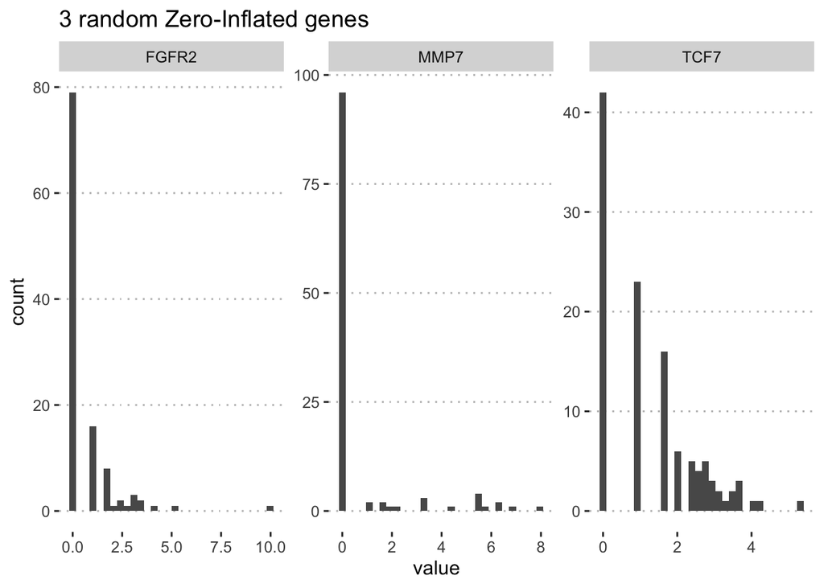

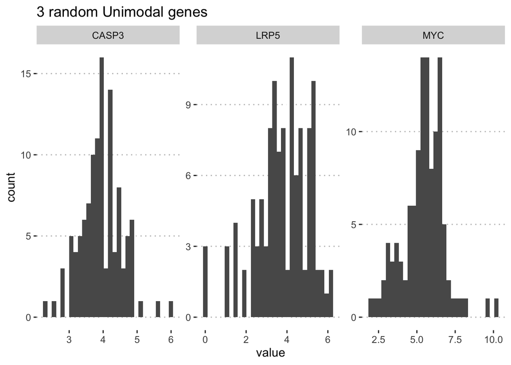

And depending on distribution category, we can perform binarization

```
## [1] "Bimodal example:"
```

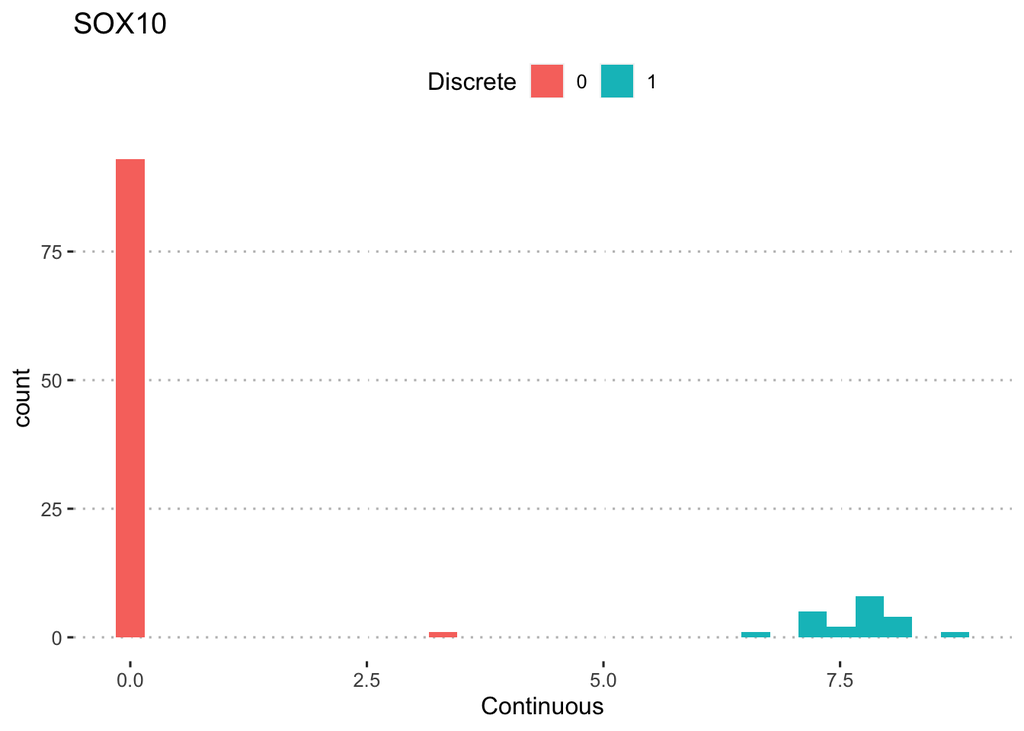

```
## [1] "Zero-Inf example:"
```

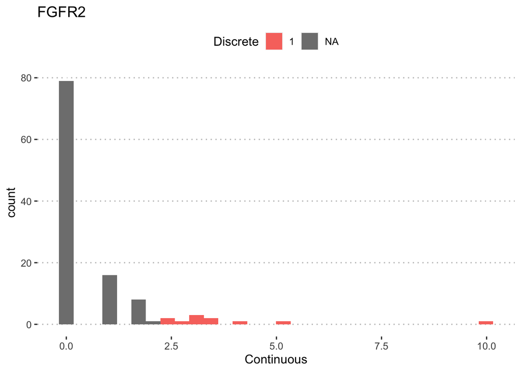

```
## [1] "Unimodal example:"
```

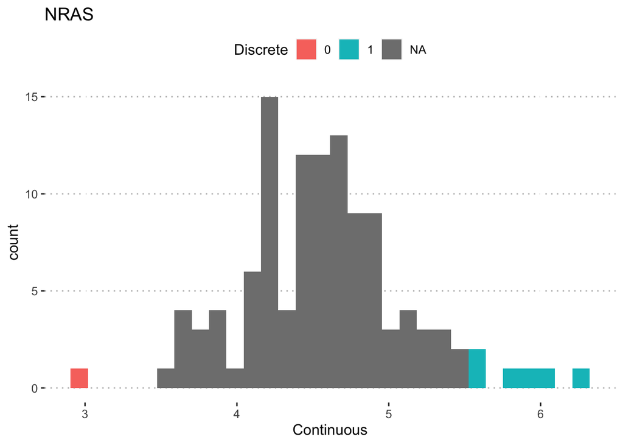

### 2.3.2 Normalization

```
## [1] "Bimodal example:"
```

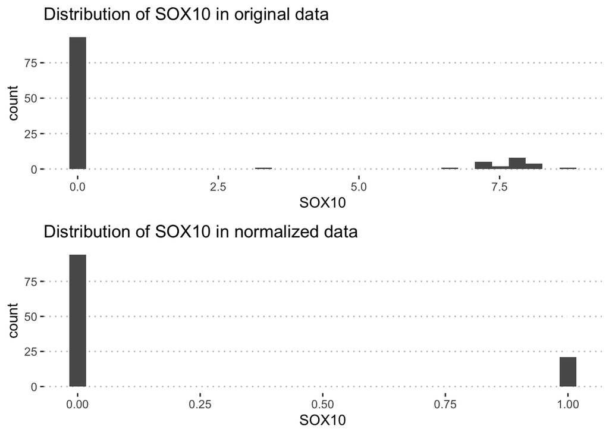

```
## [1] "Zero-Inf example:"
```

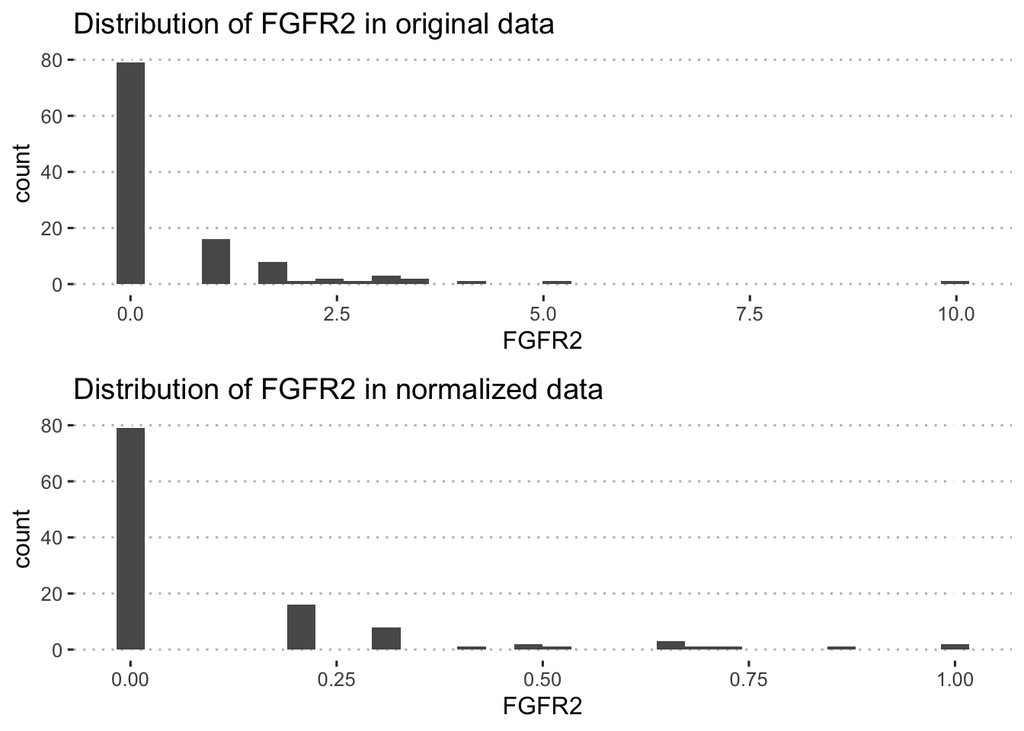

```
## [1] "Unimodal example:"
```

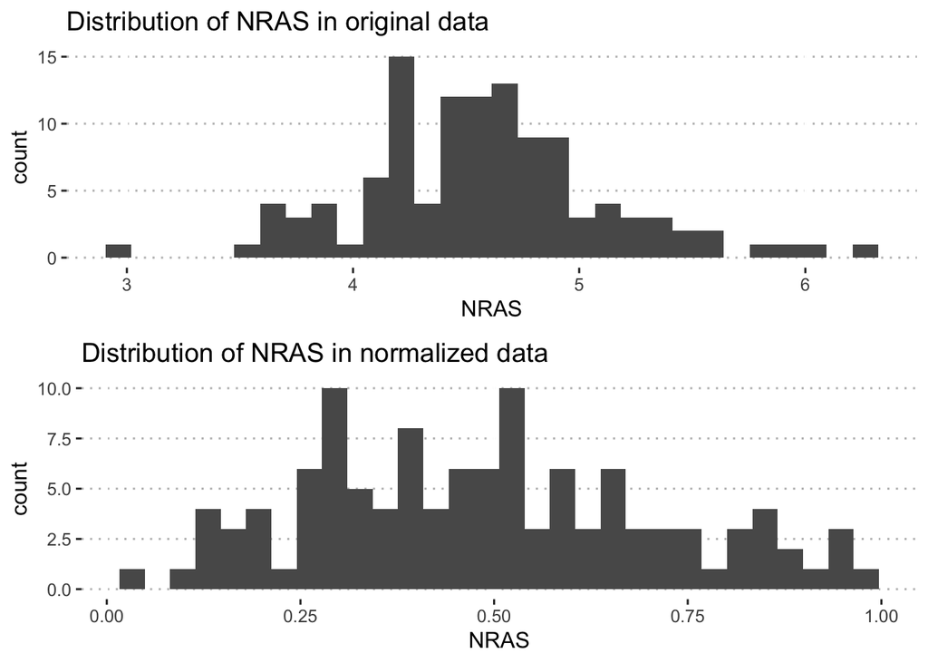

# 3 Merged profiles

## 3.1 Data types relations

Before merging independant profiles into multi-omics profiles, let's have a look at relations between data types

### 3.1.1 Mutations and CNA

In particular, is there any mutation/CNA binary inconsistency?

| Patient | Gene | Mut | CNA |
| --- | --- | --- | --- |
| HCT-15 | KRAS | 1 | 0 |
| SNU-C2B | ERBB2 | 1 | 0 |
| M14 | TP53 | 0 | 1 |

In case of ambiguity, pritority is given to mutations over CNA

### 3.1.2 CNA and RNA

| Patient | Gene | CNA | RNA |
| --- | --- | --- | --- |
| G-361 | EGFR | 1 | 0 |
| M14 | MET | 1 | 0 |
| UACC-62 | MET | 1 | 0 |
| UACC-62 | SOX10 | 1 | 0 |
| GP5d | DKK1 | 1 | 0 |
| MZ2-MEL | FZD5 | 1 | 0 |
| SK-MEL-1 | RPS6KA5 | 0 | 1 |
| LS-180 | REL | 0 | 1 |
| HCT-116 | RAC2 | 0 | 1 |
| MZ2-MEL | RAC2 | 1 | 0 |
| SH-4 | SFRP1 | 1 | 0 |

## 3.2 Write profiles

```
## [1] "Done"
```

```
## [1] "Computation time:"
```

```
## 503.48 sec elapsed
```